# The effect of QUD and prior on exhaustivity: an empirical investigation

## Part 1: Set-up

Installing packages:

```r
library(tidyverse)
library(brms)
library(forcats)
library(stringr)
library(lme4)
library(languageR)
library(ggrepel)
```

Setting theme for visualizations and adding Judith’s helper functions file

```r
theme_set(theme_bw(18))
source("helpers.r")
```

Reading in the data from the critical experiment and the norming experiment where prior beliefs were collected

```r
d = read.table(file="../data/2_critical/experiment.csv",sep=",", header=T)
# d = read.table(file="../data/1_critical/pilot.csv",sep=",", header=T)
d = as.data.frame(lapply(d, function(x) {gsub('\"',"",x)}))
priors = read.table(file="../data/1_norm/experiment.csv",sep=",", header=T)
priors = as.data.frame(lapply(priors, function(x) {gsub('\"',"",x)}))
```

Ensuring that different variables are correctly assigned as factors, numbers, and strings

```r
d$Trial = as.numeric(as.character(d$slide_number)) - 3
d$Answer.time_in_minutes = as.numeric(as.character(d$Answer.time_in_minutes))
d$age = as.numeric(as.character(d$age))
d$topic = as.factor(as.character(d$topic))
d$slide_number = as.numeric(as.character(d$slide_number))

priors$response = as.numeric(as.character(priors$response))
```

Adding the block number via reverse engineering - block_number is 1 if it is the first of the blocks, 2 otherwise

```r
d = d %>%
  group_by(workerid) %>%
  mutate(block_num = case_when (
    slide_number > 3 & slide_number < 36 & block == 'exhaustivity' & first(block) == 'exhaustivity' ~ 1,
    slide_number > 3 & slide_number < 16 & block == 'qud_assessment' & first(block) == 'qud_assessment' ~ 1,
    slide_number > 36 & slide_number < 49 & block == 'qud_assessment' & last(block) == 'qud_assessment' ~ 2,
    slide_number > 16 & slide_number < 49 & block == 'exhaustivity' & last(block) == 'exhaustivity' ~ 2)) %>%
  ungroup()
```

## Part 2: Housekeeping Plots

1. Histogram of time taken to complete the experiment (in minutes), not by participant

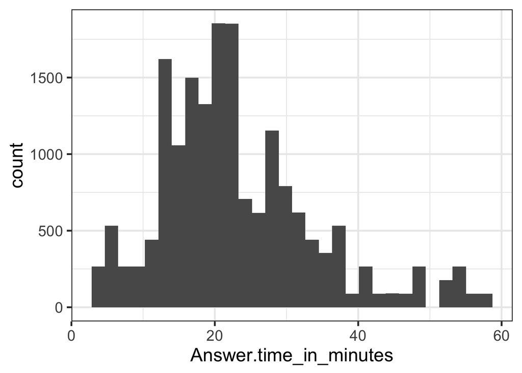

```r
ggplot(d, aes(Answer.time_in_minutes)) +
   geom_histogram()
```

2. Gender breakdown of trial (not by participant)

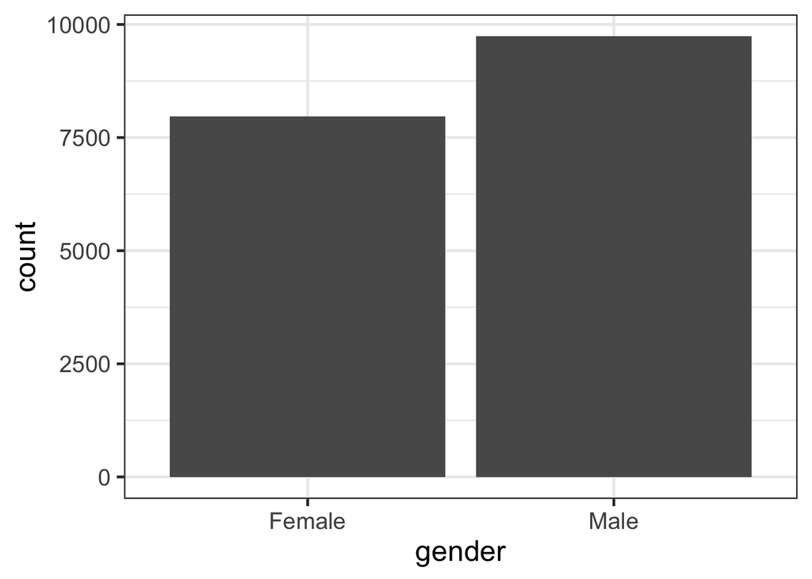

```r
ggplot(d, aes(gender)) +
   stat_count()
```

3. HIT Understanding

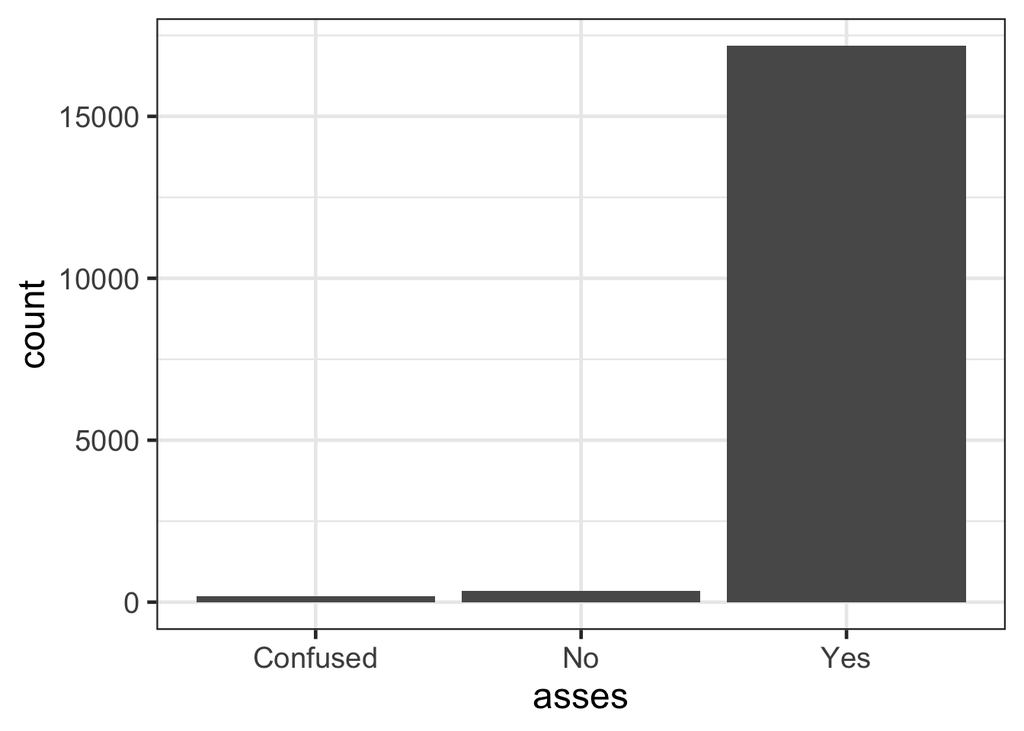

```r
ggplot(d, aes(asses)) +
   stat_count()
```

4. Histogram of age by trial

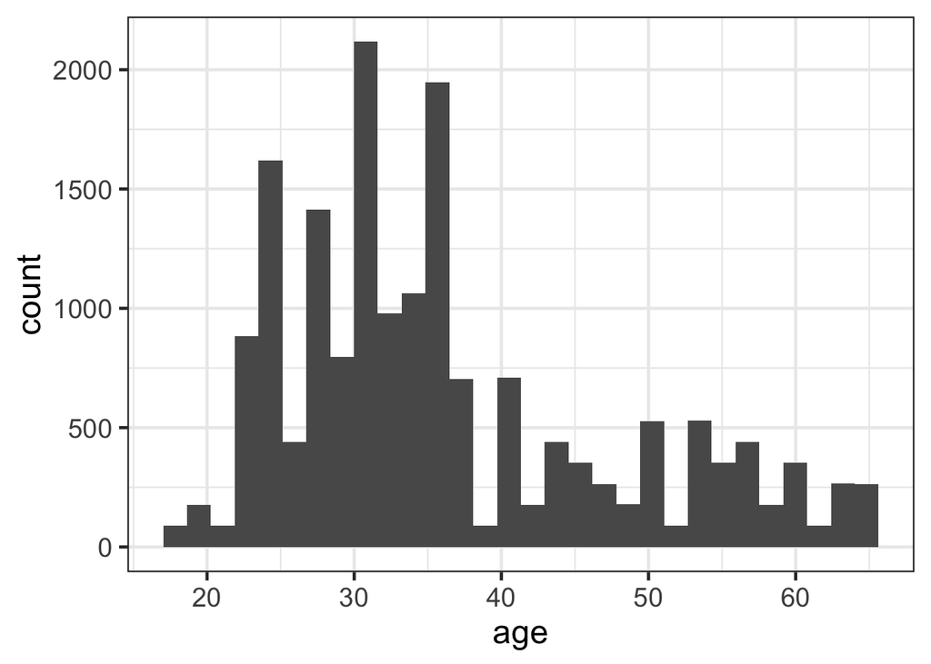

```r
ggplot(d, aes(age)) +
   geom_histogram()
```

5. Histogram of education by trial

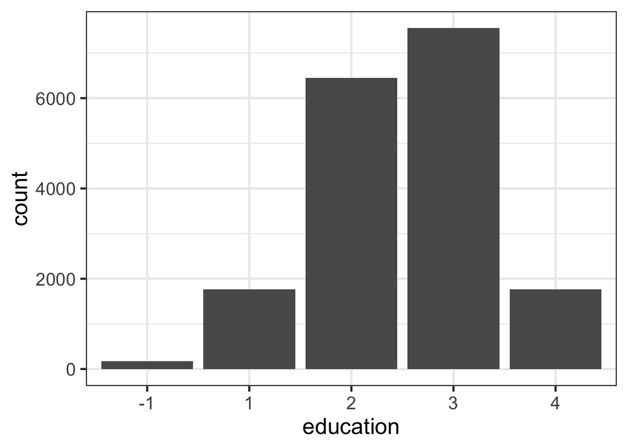

```r
ggplot(d, aes(education)) +
   stat_count()
```

6. Histogram of language by trial

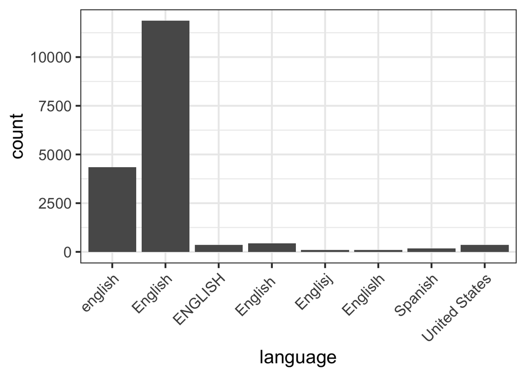

```r
ggplot(d, aes(language)) +
   stat_count() +
   theme(axis.text.x=element_text(angle=45,hjust=1,vjust=1))
```

7. Histogram of enjoyment by trial

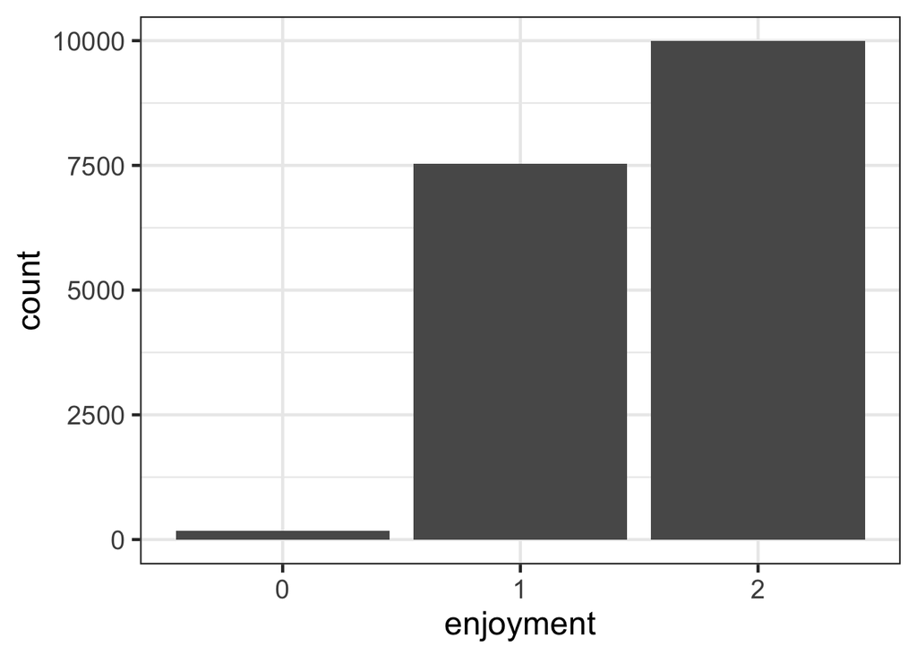

```r
ggplot(d, aes(enjoyment)) +
  stat_count()
```

## Part 3: Implementing Exclusion Criteria

```r
#Finding the failures
#Language --> 2 excluded
fails0 = d %>%
  filter(language == 'Urdu' | language == 'Italian' | language == 'Spanish' | language == 'Other') %>%
  droplevels()

#Look at spread of response times
fails1 = d %>%
  filter(Answer.time_in_minutes < 10) %>%
  droplevels()

#Slider --> 35 excluded
fails2 = d %>%
  filter((block == 'exhaustivity' & trial_type == "filler" & qud == "exhaustive" & as.numeric(as.character(response)) < 0.5) | (block == 'exhaustivity' & trial_type == "filler" & qud == "polar" & as.numeric(as.character(response)) > 0.5)) %>%
  droplevels()
#MC --> 22 excluded
fails3 = d %>% filter((block == 'qud_assessment' & trial_type == "filler" & qud == "exhaustive" & response != 'exhaustive') | (block == 'qud_assessment' &trial_type == "filler" & qud == "polar" & response != 'polar'))%>%
 droplevels()

#Filtering the failures
d = d %>%
  filter(workerid %in% fails0$workerid == FALSE & workerid %in% fails1$workerid == FALSE & workerid %in% fails2$workerid == FALSE & workerid %in% fails3$workerid == FALSE) %>%
  droplevels()
```

## Part 4: Separating the trials into block

```r
# exhaustivity block critical trials
exhaustivity = d %>%
  filter(block == 'exhaustivity') %>%
  filter(trial_type == 'critical')%>%
  droplevels()

exhaustivity$response = as.numeric(as.character(exhaustivity$response))

# qud block critical trials only
qud = d %>%
  filter(block == 'qud_assessment') %>%
  filter(trial_type == 'critical')%>%
  droplevels()
```

## Part 5: Determining sensitivity score by subject and by item

In this experiment, sensitivity score (a score that tells how susceptible slider responses are to contextual QUD manipulation) is computed by taking the proportion of exhaustive responses to trials where the context induced an exhaustive QUD and subtracting the proportion of exhaustive responses to trials where the context induced a polar QUD.

```r
#Determining by-subject sensitivity score
sensitivity = qud %>%
  group_by(workerid,qud) %>%
  summarise(Mean=mean(response == 'exhaustive')) %>%
  spread(qud,Mean) %>%
  summarise(sensitivityScore = exhaustive - polar)

#Joining by-subject sensitivity score to full datasets
qud = qud %>%
  right_join(sensitivity, by=c('workerid'))

exhaustivity = exhaustivity %>%
  right_join(sensitivity, by=c('workerid'))

#Determining something's QUD sensitivity score:
sensitivityItem = qud %>%
  group_by(topic,qud) %>%
  summarise(Mean=mean(response == 'exhaustive')) %>%
  spread(qud,Mean) %>%
  summarise(sensitivityScoreItem = exhaustive - polar)
```

8. Plotting a histogram of participant sensitivity

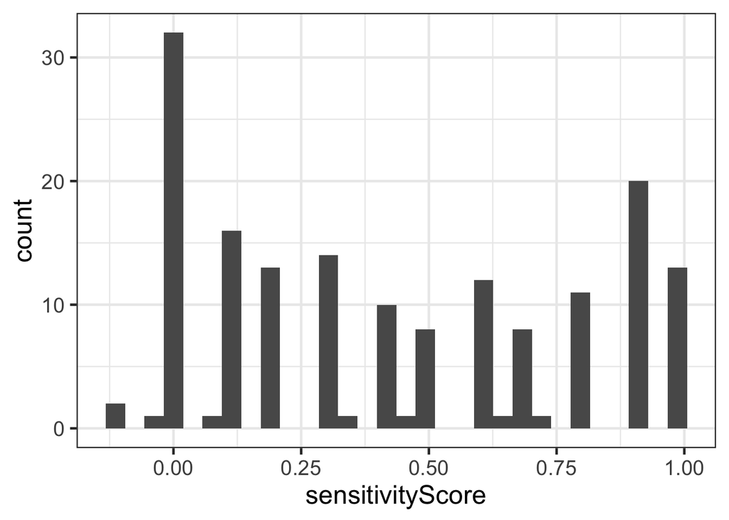

```r
ggplot(sensitivity, aes(x=sensitivityScore)) +
  geom_histogram()
```

## Part 6: Determining mean prior belief by item and integrating into experimental data

```r
#Getting mean priors over all items and adding their "topic" value
priorsItems = priors %>%
  mutate(response = 1-response) %>%
  group_by(scenario) %>%
  summarise(Mean=mean(response),CILow=ci.low(response),CIHigh=ci.high(response)) %>%
  ungroup() %>%
  mutate(YMin=Mean-CILow,YMax=Mean+CIHigh) %>%
  mutate(Mean_Prior = Mean,YMin_Prior = YMin, YMax_Prior = YMax) %>%
  mutate(Scenario = fct_reorder(scenario,Mean)) %>%
  arrange(desc(Scenario)) %>%
  cbind(data.frame(topic = c('ice cream','pottery','San Francisco','partner','cereal','gym','perfume','notUsed','fruit basket','ballad','notUsed','gas station','tulips','freestyle','notUsed','weights','notUsed','sandals','lipstick','notUsed','salmon','kale','salad','tomatoes','bell peppers'))) %>%
  select(Mean_Prior,YMin_Prior,YMax_Prior,topic,Scenario)

#Making sure topic value is a factor
priorsItems$topic = as.factor(as.character(priorsItems$topic))

#Integrating priors with data and making it so that a bigger answer is more exhaustive
exhaustivity = exhaustivity %>%
  mutate(response = 1-response) %>%
  left_join(priorsItems,by=c('topic'))
```

## Part 7: Critical visualizations

9. Mean slider response (from exhaustivity block) in polar and exhaustive QUD conditions

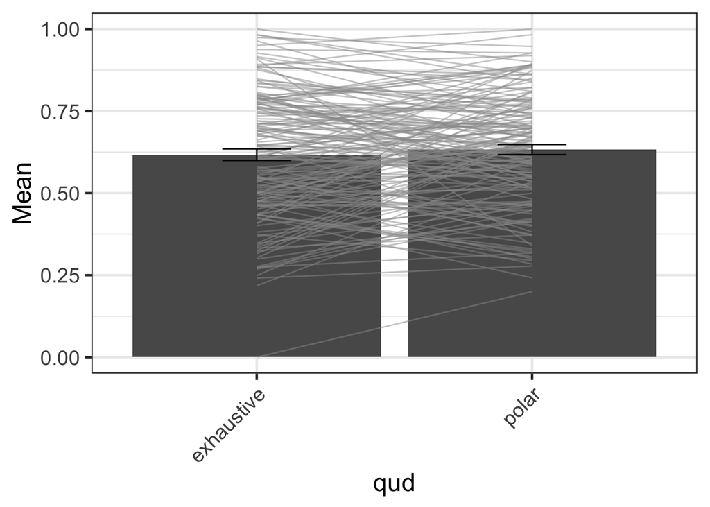

```r
means = exhaustivity %>%
  group_by(qud) %>%
  summarise(Mean=mean(response),CILow=ci.low(response),CIHigh=ci.high(response)) %>%
  ungroup() %>%
  mutate(YMin=Mean-CILow,YMax=Mean+CIHigh) %>%
  mutate(Mean_New = Mean,YMin_New = YMin, YMax_New = YMax) %>%
  mutate(Qud = fct_reorder(qud,Mean))

means_subj = exhaustivity %>%
  group_by(qud,workerid) %>%
  summarise(Mean=mean(response),CILow=ci.low(response),CIHigh=ci.high(response)) %>%
  ungroup() %>%
  mutate(YMin=Mean-CILow,YMax=Mean+CIHigh) %>%
  mutate(Mean_New = Mean,YMin_New = YMin, YMax_New = YMax) %>%
  mutate(Qud = fct_reorder(qud,Mean))

#plot of mean slider response (with error bars) per QUD
ggplot(means, aes(x=qud,y=Mean)) +
  geom_bar(stat="identity") +
  geom_line(data=means_subj,aes(group=workerid),alpha=.5,color="gray60") +
  geom_errorbar(aes(ymin=YMin,ymax=YMax),width=.25) +
  theme(axis.text.x=element_text(angle=45,hjust=1,vjust=1))
```

```r
#plot of mean slider response (with error bars) per QUD per subject
# ggplot(means_subj, aes(x=qud,y=Mean)) +
#   geom_bar(stat="identity") +
#   facet_wrap(~workerid) +
#   #geom_line(data=means_subj,aes(group=workerid),alpha=.5,color="gray60") +
#   geom_errorbar(aes(ymin=YMin,ymax=YMax),width=.25) +
#   theme(axis.text.x=element_text(angle=45,hjust=1,vjust=1))
```

10. Proportion of exhaustive responses (from QUD assessment block) in the polar and exhaustive QUD conditions, by item as a histogram

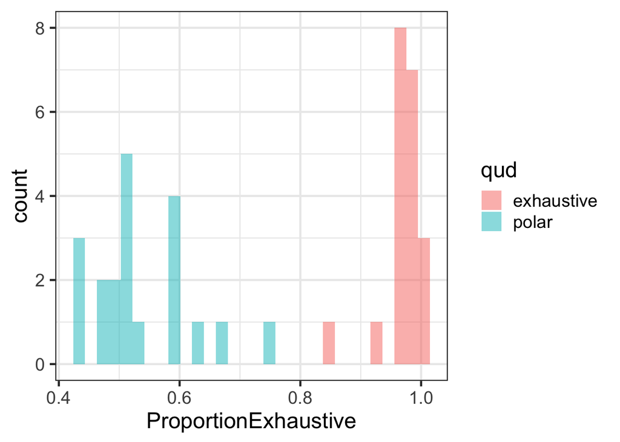

```r
#Compute proportions of exhaustive responses by qud
cont_qud = qud %>%
  group_by(topic,qud) %>%
  summarise(ProportionExhaustive = mean(response == 'exhaustive')) %>%
  ungroup()

ggplot(cont_qud,aes(x=ProportionExhaustive,fill=qud))  +
  geom_histogram(position="identity",alpha=.5)
```

11. Proportion of exhaustive responses (from QUD assessment block) in the polar and exhaustive QUD conditions, by item as a scatterplot

```r
# merge back into exhaustivity
exhaustivity = left_join(exhaustivity,cont_qud,by=c("topic","qud"))
```

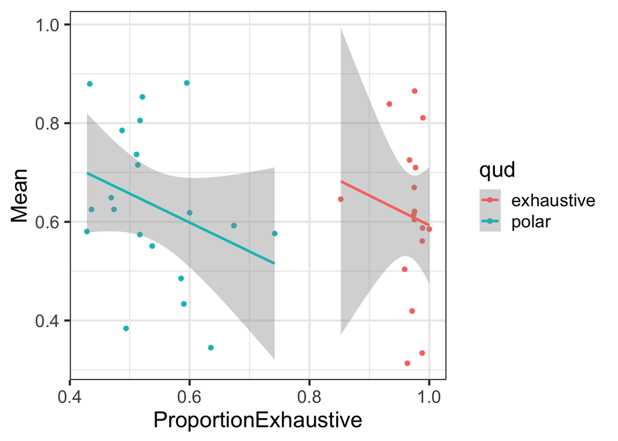

```r
means = exhaustivity %>%
  group_by(ProportionExhaustive,qud) %>%
  summarise(Mean=mean(response),CILow=ci.low(response),CIHigh=ci.high(response))%>%
  ungroup() %>%
  mutate(YMin=Mean-CILow,YMax=Mean+CIHigh)

ggplot(means,aes(x=ProportionExhaustive,y=Mean,color=qud)) +
  geom_point() +
  geom_smooth(method="lm")
```

```r
#ggsave(file="../graphs/1_critical/mean_slider_line.png")
```

Mean proportion of exhaustive responses in polar versus exhaustive QUD, as a bar plot

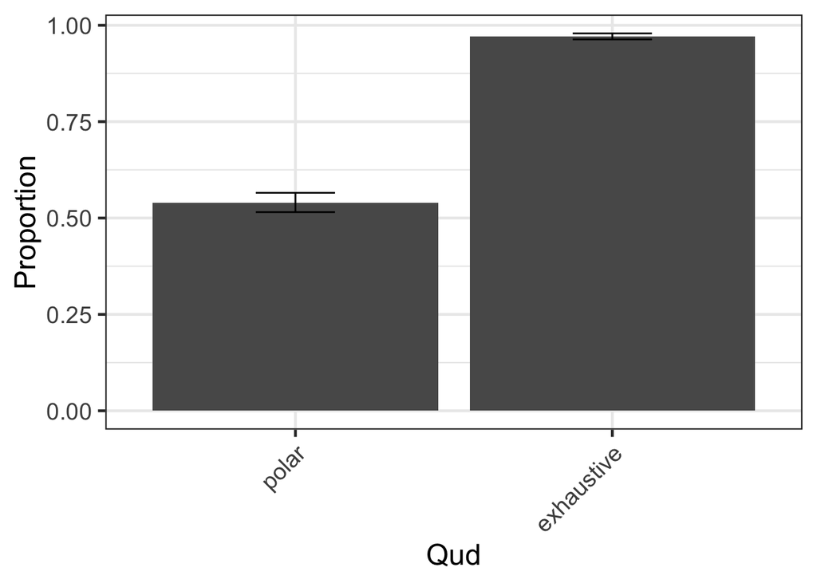

```r
#2. Mean proportion of "exhaustive" responses in the polar versus exhaustive QUD (from qud block)
meanExhaustive = qud %>%
  group_by(qud)%>%
  summarise(Proportion = mean(response == 'exhaustive'),CILow=ci.low(response == 'exhaustive'),CIHigh=ci.high(response == 'exhaustive'))%>%
  ungroup() %>%
  mutate(YMin=Proportion-CILow,YMax=Proportion+CIHigh) %>%
  mutate(Proportion_New = Proportion,YMin_New = YMin, YMax_New = YMax) %>%
  mutate(Qud = fct_reorder(qud,Proportion))

ggplot(meanExhaustive, aes(x=Qud,y=Proportion)) +
  geom_bar(stat="identity") +
  geom_errorbar(aes(ymin=YMin,ymax=YMax),width=.25) +
  theme(axis.text.x=element_text(angle=45,hjust=1,vjust=1))
```

```r
meanExhaustive = qud %>%
  group_by(qud,workerid)%>%
  summarise(Proportion = mean(response == 'exhaustive'),CILow=ci.low(response == 'exhaustive'),CIHigh=ci.high(response == 'exhaustive'))%>%
  ungroup() %>%
  mutate(YMin=Proportion-CILow,YMax=Proportion+CIHigh) %>%
  mutate(Proportion_New = Proportion,YMin_New = YMin, YMax_New = YMax) %>%
  mutate(Qud = fct_reorder(qud,Proportion))

# ggplot(meanExhaustive, aes(x=Qud,y=Proportion)) +
  # geom_bar(stat="identity") +
  # facet_wrap(~workerid) +
  # geom_errorbar(aes(ymin=YMin,ymax=YMax),width=.25) +
  # theme(axis.text.x=element_text(angle=45,hjust=1,vjust=1))
```

13. Mean proportion of “exhaustive” responses in polar versus exhaustive QUD, by item

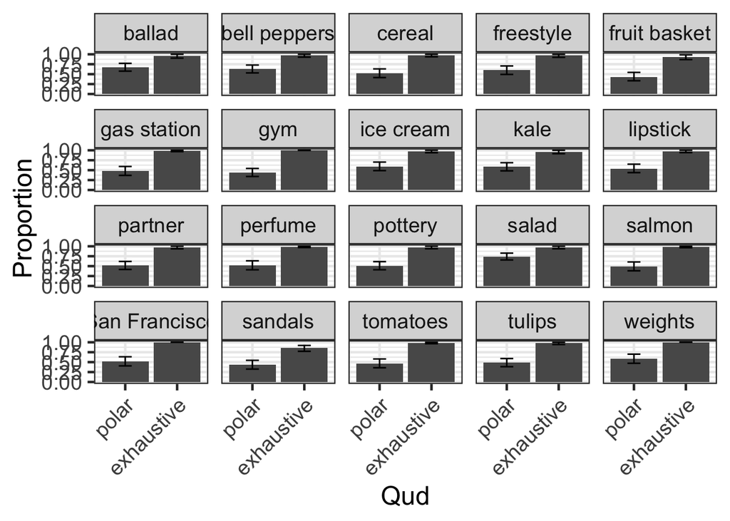

```r
meanExhaustive = qud %>%
  group_by(qud,topic)%>%
  summarise(Proportion = mean(response == 'exhaustive'),CILow=ci.low(response == 'exhaustive'),CIHigh=ci.high(response == 'exhaustive'))%>%
  ungroup() %>%
  mutate(YMin=Proportion-CILow,YMax=Proportion+CIHigh) %>%
  mutate(Proportion_New = Proportion,YMin_New = YMin, YMax_New = YMax) %>%
  mutate(Qud = fct_reorder(qud,Proportion))

ggplot(meanExhaustive, aes(x=Qud,y=Proportion)) +
  geom_bar(stat="identity") +
  facet_wrap(~topic) +
  geom_errorbar(aes(ymin=YMin,ymax=YMax),width=.25) +
  theme(axis.text.x=element_text(angle=45,hjust=1,vjust=1))
```

14. Mean slider response over sensitivity score as a scatterplot (each dot is a subject)

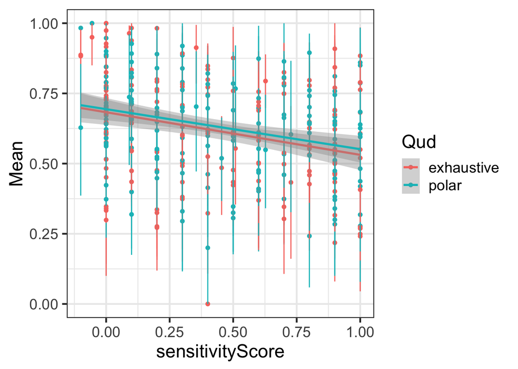

```r
means = exhaustivity %>%
  group_by(qud,workerid) %>%
  summarise(Mean = mean(response),CILow=ci.low(response),CIHigh=ci.high(response))%>%
  ungroup() %>%
  mutate(YMin=Mean-CILow,YMax=Mean+CIHigh) %>%
  mutate(Mean_New = Mean,YMin_New = YMin, YMax_New = YMax) %>%
  mutate(Qud = fct_reorder(qud,Mean)) %>%
  right_join(sensitivity,by=c("workerid"))

ggplot(means, aes(x=sensitivityScore,y=Mean,color=Qud)) +
  geom_point() +
  geom_errorbar(aes(ymin=YMin_New,ymax=YMax_New)) +
  geom_smooth(method='lm')
```

15. Mean slider response over sensitivity score as a scatterplot (each dot is an item)

```r
means = exhaustivity %>%
  group_by(qud,topic) %>%
  summarise(Mean = mean(response),CILow=ci.low(response),CIHigh=ci.high(response))%>%
  ungroup() %>%
  mutate(YMin=Mean-CILow,YMax=Mean+CIHigh) %>%
  mutate(Mean_New = Mean,YMin_New = YMin, YMax_New = YMax) %>%
  mutate(Qud = fct_reorder(qud,Mean)) %>%
  right_join(sensitivityItem,by=c("topic"))
```

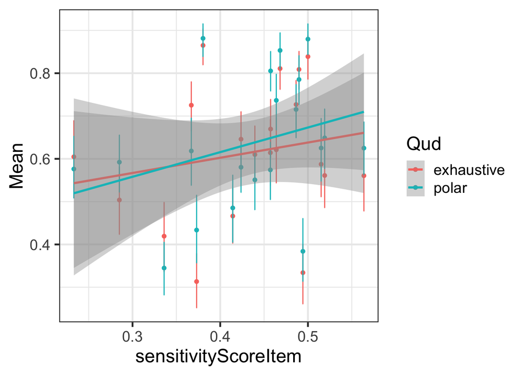

```r
ggplot(means, aes(x=sensitivityScoreItem,y=Mean,color=Qud)) +
  geom_point() +
  geom_errorbar(aes(ymin=YMin_New,ymax=YMax_New)) +
  geom_smooth(method='lm')
```

16. Slider response over sensitivity score per trial as a scatterplot

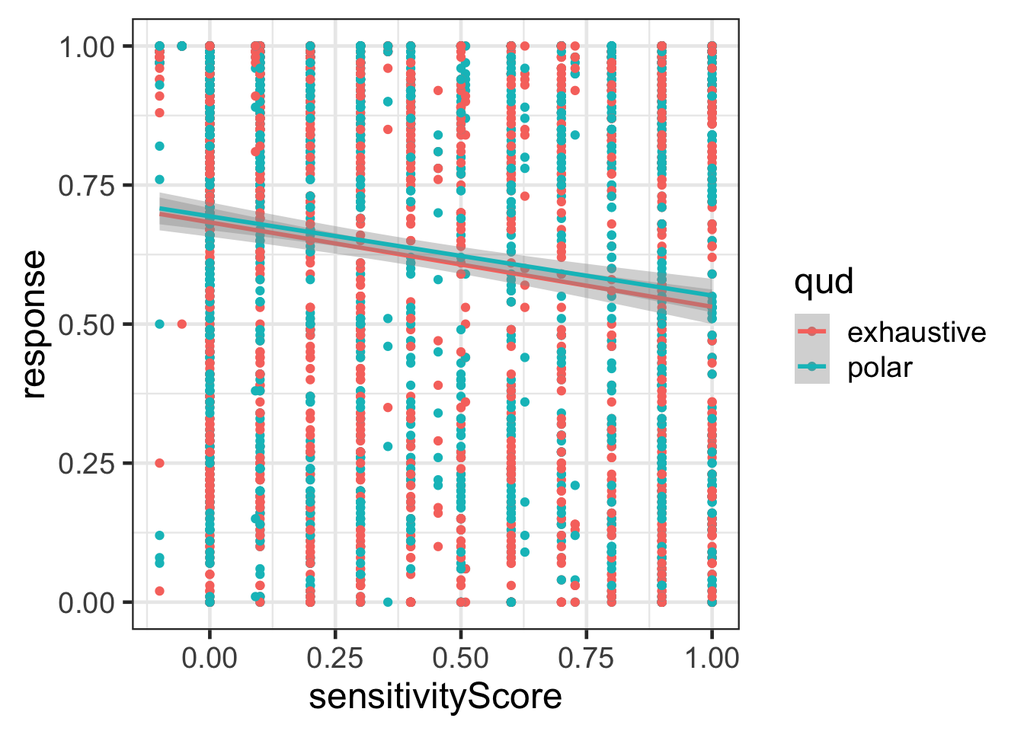

```r
ggplot(exhaustivity, aes(x=sensitivityScore,y=response,color=qud)) +
  geom_point() +
  geom_smooth(method='lm')
```

17. Mean slider response over prior beliefs as a scatterplot (each dot is an item)

```r
means = exhaustivity %>%
  group_by(qud,topic) %>%
  summarise(Mean = mean(response),CILow=ci.low(response),CIHigh=ci.high(response))%>%
  ungroup() %>%
  mutate(YMin=Mean-CILow,YMax=Mean+CIHigh) %>%
  mutate(Mean_New = Mean,YMin_New = YMin, YMax_New = YMax) %>%
  mutate(Qud = fct_reorder(qud,Mean)) %>%
  left_join(priorsItems,by=c("topic"))
```

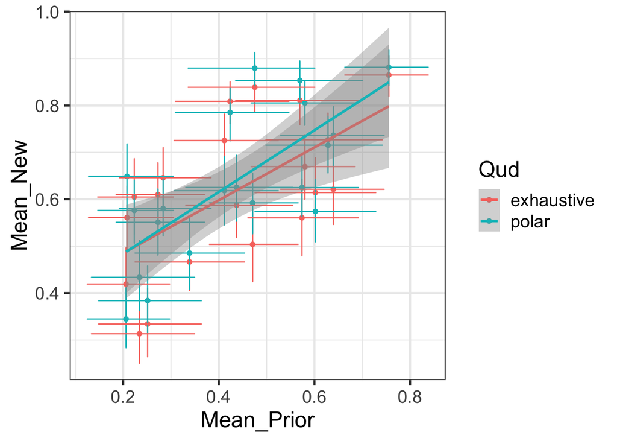

```r
ggplot(means, aes(x=Mean_Prior,y=Mean_New,color=Qud)) +
  geom_point() +
  geom_errorbar(aes(ymin=YMin_New,ymax=YMax_New)) +
  geom_errorbarh(aes(xmin=YMin_Prior,xmax=YMax_Prior)) +
  geom_smooth(method='lm')
```

```r
#cut sensitivity into bins, plot scatterplot of prior on x-axis, exhaustivity on y axis (per subject) with lines of best fit for polar and exhaustive qud, where the exhaustivity block was presented first and second (2 x 2)
```

```r
means = exhaustivity %>%
  group_by(qud,topic) %>%
  summarise(Mean = mean(response),CILow=ci.low(response),CIHigh=ci.high(response))%>%
  ungroup() %>%
  mutate(YMin=Mean-CILow,YMax=Mean+CIHigh) %>%
  mutate(Mean_New = Mean,YMin_New = YMin, YMax_New = YMax) %>%
  mutate(Qud = fct_reorder(qud,Mean)) %>%
  left_join(priorsItems,by=c("topic")) %>%
  left_join(sensitivityItem,by=c("topic")) %>%
  mutate(sensitivityBinned = ntile(sensitivityScoreItem, 2)) %>%
  mutate(sensitivityBinned = case_when(
    sensitivityBinned == 1 ~ "insensitive",
    sensitivityBinned == 2 ~ "max sensitive",
    TRUE ~ "somewhat sensitive"
  ))
```

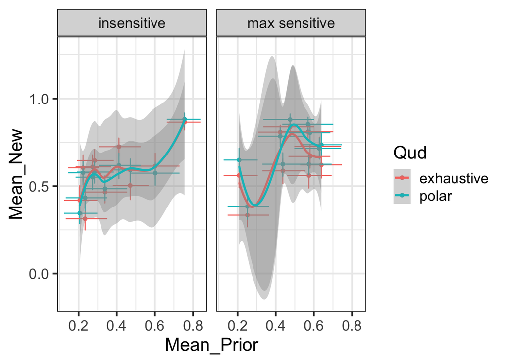

```r
ggplot(means, aes(x=Mean_Prior,y=Mean_New,color=Qud)) +
  geom_point() +
  facet_wrap(~sensitivityBinned) +
  geom_errorbar(aes(ymin=YMin_New,ymax=YMax_New)) +
  geom_errorbarh(aes(xmin=YMin_Prior,xmax=YMax_Prior)) +
  geom_smooth()
```